# Final Project - OPTION 2: The Comprehensive ML Pipeline

## Part A: Data Preprocessing & Exploratory Analysis

### Import required libraries

```python
import pandas as pd
import numpy as np

import matplotlib.pyplot as plt
import seaborn as sns

from sklearn.datasets import load_breast_cancer
from sklearn.preprocessing import StandardScaler
```

### Load the dataset and separate features and target

```python
# Load the breast cancer dataset
cancer_data = load_breast_cancer()

# Store the input features in a DataFrame
X = pd.DataFrame(cancer_data.data, columns=cancer_data.feature_names)

# Store the target labels separately
y = pd.Series(cancer_data.target, name="target")

# Combine features and target for easier exploration
df = X.copy()
df["target"] = y

# Add readable class names
df["diagnosis"] = df["target"].map({0: "malignant", 1: "benign"})
```

### Basic dataset inspection

```python
# Check the size of the dataset
print("Feature matrix shape:", X.shape)
print("Target vector shape:", y.shape)

# Check the first few rows
display(df.head())

# Count how many samples belong to each class
print("\nClass distribution:")
print(df["diagnosis"].value_counts())

# Check if there are missing values
print("\nTotal missing values:", X.isnull().sum().sum())
```

```
Feature matrix shape: (569, 30)
Target vector shape: (569,)
```

|  | mean radius | mean texture | mean perimeter | mean area | mean smoothness | mean compactness | mean concavity | mean concave points | mean symmetry | mean fractal dimension | ... | worst perimeter | worst area | worst smoothness | worst compactness | worst concavity | worst concave points | worst symmetry | worst fractal dimension | target | diagnosis |
| --- | --- | --- | --- | --- | --- | --- | --- | --- | --- | --- | --- | --- | --- | --- | --- | --- | --- | --- | --- | --- | --- |
| 0 | 17.99 | 10.38 | 122.80 | 1001.0 | 0.11840 | 0.27760 | 0.3001 | 0.14710 | 0.2419 | 0.07871 | ... | 184.60 | 2019.0 | 0.1622 | 0.6656 | 0.7119 | 0.2654 | 0.4601 | 0.11890 | 0 | malignant |
| 1 | 20.57 | 17.77 | 132.90 | 1326.0 | 0.08474 | 0.07864 | 0.0869 | 0.07017 | 0.1812 | 0.05667 | ... | 158.80 | 1956.0 | 0.1238 | 0.1866 | 0.2416 | 0.1860 | 0.2750 | 0.08902 | 0 | malignant |
| 2 | 19.69 | 21.25 | 130.00 | 1203.0 | 0.10960 | 0.15990 | 0.1974 | 0.12790 | 0.2069 | 0.05999 | ... | 152.50 | 1709.0 | 0.1444 | 0.4245 | 0.4504 | 0.2430 | 0.3613 | 0.08758 | 0 | malignant |
| 3 | 11.42 | 20.38 | 77.58 | 386.1 | 0.14250 | 0.28390 | 0.2414 | 0.10520 | 0.2597 | 0.09744 | ... | 98.87 | 567.7 | 0.2098 | 0.8663 | 0.6869 | 0.2575 | 0.6638 | 0.17300 | 0 | malignant |
| 4 | 20.29 | 14.34 | 135.10 | 1297.0 | 0.10030 | 0.13280 | 0.1980 | 0.10430 | 0.1809 | 0.05883 | ... | 152.20 | 1575.0 | 0.1374 | 0.2050 | 0.4000 | 0.1625 | 0.2364 | 0.07678 | 0 | malignant |

5 rows × 32 columns

```
Class distribution:
diagnosis
benign       357
malignant    212
Name: count, dtype: int64

Total missing values: 0
```

### Summary statistics

```python
# Look at basic statistics for the features
display(X.describe().T)
```

|  | count | mean | std | min | 25% | 50% | 75% | max |
| --- | --- | --- | --- | --- | --- | --- | --- | --- |
| mean radius | 569.0 | 14.127292 | 3.524049 | 6.981000 | 11.700000 | 13.370000 | 15.780000 | 28.11000 |
| mean texture | 569.0 | 19.289649 | 4.301036 | 9.710000 | 16.170000 | 18.840000 | 21.800000 | 39.28000 |
| mean perimeter | 569.0 | 91.969033 | 24.298981 | 43.790000 | 75.170000 | 86.240000 | 104.100000 | 188.50000 |
| mean area | 569.0 | 654.889104 | 351.914129 | 143.500000 | 420.300000 | 551.100000 | 782.700000 | 2501.00000 |
| mean smoothness | 569.0 | 0.096360 | 0.014064 | 0.052630 | 0.086370 | 0.095870 | 0.105300 | 0.16340 |
| mean compactness | 569.0 | 0.104341 | 0.052813 | 0.019380 | 0.064920 | 0.092630 | 0.130400 | 0.34540 |
| mean concavity | 569.0 | 0.088799 | 0.079720 | 0.000000 | 0.029560 | 0.061540 | 0.130700 | 0.42680 |
| mean concave points | 569.0 | 0.048919 | 0.038803 | 0.000000 | 0.020310 | 0.033500 | 0.074000 | 0.20120 |
| mean symmetry | 569.0 | 0.181162 | 0.027414 | 0.106000 | 0.161900 | 0.179200 | 0.195700 | 0.30400 |
| mean fractal dimension | 569.0 | 0.062798 | 0.007060 | 0.049960 | 0.057700 | 0.061540 | 0.066120 | 0.09744 |
| radius error | 569.0 | 0.405172 | 0.277313 | 0.111500 | 0.232400 | 0.324200 | 0.478900 | 2.87300 |
| texture error | 569.0 | 1.216853 | 0.551648 | 0.360200 | 0.833900 | 1.108000 | 1.474000 | 4.88500 |
| perimeter error | 569.0 | 2.866059 | 2.021855 | 0.757000 | 1.606000 | 2.287000 | 3.357000 | 21.98000 |
| area error | 569.0 | 40.337079 | 45.491006 | 6.802000 | 17.850000 | 24.530000 | 45.190000 | 542.20000 |
| smoothness error | 569.0 | 0.007041 | 0.003003 | 0.001713 | 0.005169 | 0.006380 | 0.008146 | 0.03113 |
| compactness error | 569.0 | 0.025478 | 0.017908 | 0.002252 | 0.013080 | 0.020450 | 0.032450 | 0.13540 |
| concavity error | 569.0 | 0.031894 | 0.030186 | 0.000000 | 0.015090 | 0.025890 | 0.042050 | 0.39600 |
| concave points error | 569.0 | 0.011796 | 0.006170 | 0.000000 | 0.007638 | 0.010930 | 0.014710 | 0.05279 |
| symmetry error | 569.0 | 0.020542 | 0.008266 | 0.007882 | 0.015160 | 0.018730 | 0.023480 | 0.07895 |
| fractal dimension error | 569.0 | 0.003795 | 0.002646 | 0.000895 | 0.002248 | 0.003187 | 0.004558 | 0.02984 |
| worst radius | 569.0 | 16.269190 | 4.833242 | 7.930000 | 13.010000 | 14.970000 | 18.790000 | 36.04000 |
| worst texture | 569.0 | 25.677223 | 6.146258 | 12.020000 | 21.080000 | 25.410000 | 29.720000 | 49.54000 |
| worst perimeter | 569.0 | 107.261213 | 33.602542 | 50.410000 | 84.110000 | 97.660000 | 125.400000 | 251.20000 |
| worst area | 569.0 | 880.583128 | 569.356993 | 185.200000 | 515.300000 | 686.500000 | 1084.000000 | 4254.00000 |
| worst smoothness | 569.0 | 0.132369 | 0.022832 | 0.071170 | 0.116600 | 0.131300 | 0.146000 | 0.22260 |
| worst compactness | 569.0 | 0.254265 | 0.157336 | 0.027290 | 0.147200 | 0.211900 | 0.339100 | 1.05800 |
| worst concavity | 569.0 | 0.272188 | 0.208624 | 0.000000 | 0.114500 | 0.226700 | 0.382900 | 1.25200 |
| worst concave points | 569.0 | 0.114606 | 0.065732 | 0.000000 | 0.064930 | 0.099930 | 0.161400 | 0.29100 |
| worst symmetry | 569.0 | 0.290076 | 0.061867 | 0.156500 | 0.250400 | 0.282200 | 0.317900 | 0.66380 |
| worst fractal dimension | 569.0 | 0.083946 | 0.018061 | 0.055040 | 0.071460 | 0.080040 | 0.092080 | 0.20750 |

### Standardize the numerical features

```python
# Create the scaler object
scaler = StandardScaler()

# Fit the scaler and transform the feature values
X_scaled_array = scaler.fit_transform(X)

# Convert the scaled data back into a DataFrame
X_scaled = pd.DataFrame(X_scaled_array, columns=X.columns)

# Display the first few scaled rows
display(X_scaled.head())
```

|  | mean radius | mean texture | mean perimeter | mean area | mean smoothness | mean compactness | mean concavity | mean concave points | mean symmetry | mean fractal dimension | ... | worst radius | worst texture | worst perimeter | worst area | worst smoothness | worst compactness | worst concavity | worst concave points | worst symmetry | worst fractal dimension |
| --- | --- | --- | --- | --- | --- | --- | --- | --- | --- | --- | --- | --- | --- | --- | --- | --- | --- | --- | --- | --- | --- |
| 0 | 1.097064 | -2.073335 | 1.269934 | 0.984375 | 1.568466 | 3.283515 | 2.652874 | 2.532475 | 2.217515 | 2.255747 | ... | 1.886690 | -1.359293 | 2.303601 | 2.001237 | 1.307686 | 2.616665 | 2.109526 | 2.296076 | 2.750622 | 1.937015 |
| 1 | 1.829821 | -0.353632 | 1.685955 | 1.908708 | -0.826962 | -0.487072 | -0.023846 | 0.548144 | 0.001392 | -0.868652 | ... | 1.805927 | -0.369203 | 1.535126 | 1.890489 | -0.375612 | -0.430444 | -0.146749 | 1.087084 | -0.243890 | 0.281190 |
| 2 | 1.579888 | 0.456187 | 1.566503 | 1.558884 | 0.942210 | 1.052926 | 1.363478 | 2.037231 | 0.939685 | -0.398008 | ... | 1.511870 | -0.023974 | 1.347475 | 1.456285 | 0.527407 | 1.082932 | 0.854974 | 1.955000 | 1.152255 | 0.201391 |
| 3 | -0.768909 | 0.253732 | -0.592687 | -0.764464 | 3.283553 | 3.402909 | 1.915897 | 1.451707 | 2.867383 | 4.910919 | ... | -0.281464 | 0.133984 | -0.249939 | -0.550021 | 3.394275 | 3.893397 | 1.989588 | 2.175786 | 6.046041 | 4.935010 |
| 4 | 1.750297 | -1.151816 | 1.776573 | 1.826229 | 0.280372 | 0.539340 | 1.371011 | 1.428493 | -0.009560 | -0.562450 | ... | 1.298575 | -1.466770 | 1.338539 | 1.220724 | 0.220556 | -0.313395 | 0.613179 | 0.729259 | -0.868353 | -0.397100 |

5 rows × 30 columns

### Why scaling is critical?

Standardization changes each feature to make sure that it has a mean close to 0 and a standard deviation close to 1. But, this does not remove the pattern in the data. It only changes the scale of the feature values.

Scaling is critical for several models used later in the pipeline. Logistic Regression can train more smoothly when features are on a similar scale. SVM with an RBF kernel depends on distance between points. So large scale features can dominate if the data is not scaled. PCA is also affected by feature scale as it looks for directions with high variance. K-Means clustering is distance-based, so scaling is very important there too.

Decision Trees are usually less sensitive to scaling, but since this project compares multiple models, it is still useful to keep the preprocessing consistent.

### Check scaling result

```python
# Compare the scaled feature means and standard deviations
scaling_check = pd.DataFrame({
    "Scaled Mean": X_scaled.mean().round(2),
    "Scaled Std": X_scaled.std().round(2)
})

display(scaling_check.head(10))
```

|  | Scaled Mean | Scaled Std |
| --- | --- | --- |
| mean radius | -0.0 | 1.0 |
| mean texture | -0.0 | 1.0 |
| mean perimeter | -0.0 | 1.0 |
| mean area | -0.0 | 1.0 |
| mean smoothness | 0.0 | 1.0 |
| mean compactness | -0.0 | 1.0 |
| mean concavity | -0.0 | 1.0 |
| mean concave points | 0.0 | 1.0 |
| mean symmetry | -0.0 | 1.0 |
| mean fractal dimension | -0.0 | 1.0 |

### Visualization 1 — Scatter plot of two important features

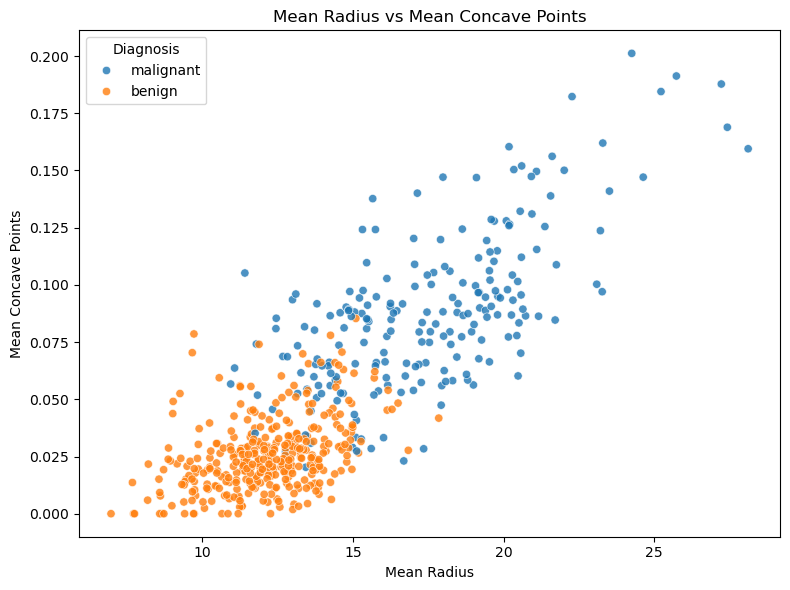

```python
# Scatter plot to compare two features by diagnosis type
plt.figure(figsize=(8, 6))

sns.scatterplot(
    data=df,
    x="mean radius",
    y="mean concave points",
    hue="diagnosis",
    alpha=0.8
)

plt.title("Mean Radius vs Mean Concave Points")
plt.xlabel("Mean Radius")
plt.ylabel("Mean Concave Points")
plt.legend(title="Diagnosis")
plt.tight_layout()
plt.show()
```

### Explanation/Observation

This scatter plot compares two features: mean radius and mean concave points.

Each point represents one tumor sample. The color shows whether the tumor is malignant or benign.

In general, malignant tumors tend to have larger radius values and more concave points compared to benign tumors. Benign tumors usually appear more toward the lower-left region of the plot.

However, the separation is not perfect and some points overlap between the two classes. This means a simple rule using only two features may not classify every tumor correctly.

### Visualization 2 — Correlation heatmap

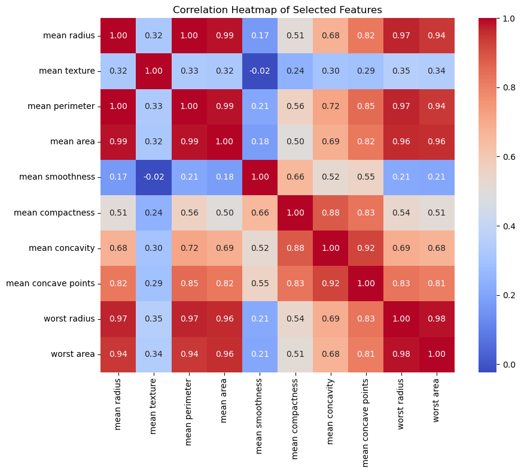

```python
# Select a smaller group of useful features for a readable heatmap
selected_features = [
    "mean radius",
    "mean texture",
    "mean perimeter",
    "mean area",
    "mean smoothness",
    "mean compactness",
    "mean concavity",
    "mean concave points",
    "worst radius",
    "worst area"
]

# Create the correlation matrix
corr_matrix = df[selected_features].corr()

# Plot the heatmap
plt.figure(figsize=(10, 8))

sns.heatmap(
    corr_matrix,
    annot=True,
    fmt=".2f",
    cmap="coolwarm",
    square=True
)

plt.title("Correlation Heatmap of Selected Features")
plt.tight_layout()
plt.show()
```

### Explanation / Observation

This heatmap shows the correlation between selected features.

Correlation measures how strongly two features move together. A value close to 1 means the two features increase together. A value close to -1 means one feature increases while the other decreases. A value near 0 means there is little linear relationship.

From the heatmap, features related to tumor size, such as `mean radius`, `mean perimeter`, `mean area`, `worst radius`, and `worst area`, are usually highly correlated. This makes sense because larger tumors often have larger radius, perimeter, and area values at the same time.

This also tells us that some features may contain overlapping information. Later, PCA can help reduce the number of dimensions by combining correlated features into fewer principal components.

## Part B: Unsupervised Learning & Dimensionality Reduction

### Import PCA, K-Means, and evaluation tools

```python
# Tools for PCA and clustering
from sklearn.decomposition import PCA
from sklearn.cluster import KMeans

# Tool to compare clustering result with actual labels
from sklearn.metrics import adjusted_rand_score
```

### Apply PCA to the dataset

```python
# Create PCA object using all components first
pca = PCA()

# Fit PCA on the scaled feature data
pca.fit(X_scaled)

# Store the explained variance values
explained_variance = pca.explained_variance_ratio_

# Calculate cumulative explained variance
cumulative_variance = explained_variance.cumsum()
```

### Find number of components needed for 90% variance

```python
# Find the first component count that reaches at least 90% variance
components_90 = np.argmax(cumulative_variance >= 0.90) + 1

print("Number of components needed for at least 90% variance:", components_90)
print("Cumulative variance at this point:", cumulative_variance[components_90 - 1])
```

```
Number of components needed for at least 90% variance: 7
Cumulative variance at this point: 0.910095300696731
```

### Plot cumulative explained variance for better understanding

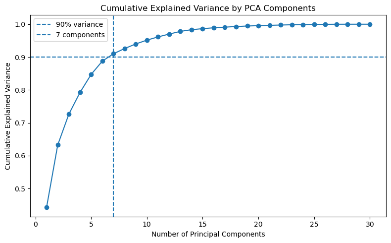

```python
# Plot how much variance is explained as components are added
plt.figure(figsize=(8, 5))

plt.plot(
    range(1, len(cumulative_variance) + 1),
    cumulative_variance,
    marker="o"
)

plt.axhline(y=0.90, linestyle="--", label="90% variance")
plt.axvline(x=components_90, linestyle="--", label=f"{components_90} components")

plt.title("Cumulative Explained Variance by PCA Components")
plt.xlabel("Number of Principal Components")
plt.ylabel("Cumulative Explained Variance")
plt.legend()
plt.tight_layout()
plt.show()
```

### How many components are required to explain at least 90% of the variance in the data?

After applying PCA to the standardized feature set, I found that 7 principal components are needed to explain at least 90% of the variance in the data.

### Create first two principal components for using in K-Means and visualization

```python
# Reduce the scaled data to only two principal components
pca_2 = PCA(n_components=2)

# Transform the data into two PCA dimensions
X_pca_2 = pca_2.fit_transform(X_scaled)

# Store the two principal components in a DataFrame
pca_df = pd.DataFrame(
    X_pca_2,
    columns=["PC1", "PC2"]
)

# Add actual labels for later comparison
pca_df["target"] = y.values
pca_df["diagnosis"] = pca_df["target"].map({0: "malignant", 1: "benign"})

display(pca_df.head())
```

|  | PC1 | PC2 | target | diagnosis |
| --- | --- | --- | --- | --- |
| 0 | 9.192837 | 1.948583 | 0 | malignant |
| 1 | 2.387802 | -3.768172 | 0 | malignant |
| 2 | 5.733896 | -1.075174 | 0 | malignant |
| 3 | 7.122953 | 10.275589 | 0 | malignant |
| 4 | 3.935302 | -1.948072 | 0 | malignant |

### Scatter plot using actual labels

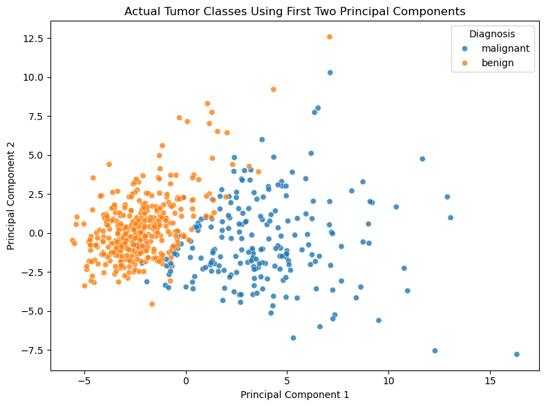

```python
# Plot the real diagnosis labels on the first two principal components
plt.figure(figsize=(8, 6))

sns.scatterplot(
    data=pca_df,
    x="PC1",
    y="PC2",
    hue="diagnosis",
    alpha=0.8
)

plt.title("Actual Tumor Classes Using First Two Principal Components")
plt.xlabel("Principal Component 1")
plt.ylabel("Principal Component 2")
plt.legend(title="Diagnosis")
plt.tight_layout()
plt.show()
```

### Apply K-Means clustering

```python
# Create K-Means with two clusters
kmeans = KMeans(n_clusters=2, random_state=42, n_init=10)

# Fit K-Means and get cluster labels
cluster_labels = kmeans.fit_predict(X_scaled)

# Add cluster labels to the PCA DataFrame
pca_df["cluster"] = cluster_labels

display(pca_df.head())
```

|  | PC1 | PC2 | target | diagnosis | cluster |
| --- | --- | --- | --- | --- | --- |
| 0 | 9.192837 | 1.948583 | 0 | malignant | 1 |
| 1 | 2.387802 | -3.768172 | 0 | malignant | 1 |
| 2 | 5.733896 | -1.075174 | 0 | malignant | 1 |
| 3 | 7.122953 | 10.275589 | 0 | malignant | 1 |
| 4 | 3.935302 | -1.948072 | 0 | malignant | 1 |

### Plot K-Means clusters using first two principal components

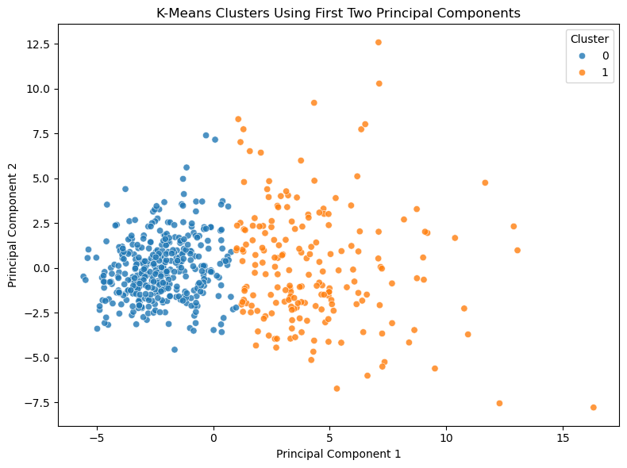

```python
# Plot the K-Means clusters on the PCA space
plt.figure(figsize=(8, 6))

sns.scatterplot(
    data=pca_df,
    x="PC1",
    y="PC2",
    hue="cluster",
    alpha=0.8
)

plt.title("K-Means Clusters Using First Two Principal Components")
plt.xlabel("Principal Component 1")
plt.ylabel("Principal Component 2")
plt.legend(title="Cluster")
plt.tight_layout()
plt.show()
```

### Explanation/Observation/Analysis:

This plot shows the K-Means clustering result using the first two principal components as the x-axis and y-axis.

K-Means was trained using all standardized features, not only PC1 and PC2. However, we use PC1 and PC2 for visualization because they allow us to draw the clustering result in two dimensions.

The K-Means clustering result is reasonably similar to the actual tumor classes. In the actual-label plot, benign tumors are mostly grouped on the left side, while malignant tumors are mostly spread toward the right side. In the K-Means plot, the algorithm also separates the data into two main groups in a similar left-right pattern.

However, the cluster numbers/colors do not directly mean malignant or benign. K-Means only labels the groups as Cluster 0 and Cluster 1. From the plots, Cluster 0 appears to mostly match the benign group, and Cluster 1 appears to mostly match the malignant group.

The clustering is not perfect. There are some points near the middle where the two groups overlap. This means some tumors are harder to separate using only unsupervised clustering. Overall, K-Means was able to find a natural pattern in the data, but it should not be used alone for medical diagnosis because some samples may still be grouped incorrectly.

```python
# Compare cluster labels with real diagnosis labels
comparison_table = pd.crosstab(
    pca_df["cluster"],
    pca_df["diagnosis"]
)

display(comparison_table)

# Calculate a clustering similarity score
ari_score = adjusted_rand_score(pca_df["target"], pca_df["cluster"])

print("Adjusted Rand Index:", ari_score)
```

| diagnosis cluster | benign | malignant |
| --- | --- | --- |
| 0 | 339 | 36 |
| 1 | 18 | 176 |

```
Adjusted Rand Index: 0.6536246043910179
```

### Analysis

The comparison table shows the precise distribution and we can see that the K-Means separated the data fairly well. Cluster 0 contains mostly benign tumors, with 339 benign samples and only 36 malignant samples. Cluster 1 contains mostly malignant tumors, with 176 malignant samples and only 18 benign samples.

This means the clustering algorithm was able to find a natural pattern in the dataset without using the real diagnosis labels during training. However, it was not perfect because some malignant tumors were placed in the mostly benign cluster, and some benign tumors were placed in the mostly malignant cluster.

The Adjusted Rand Index is about 0.65, which suggests a reasonably good match between the K-Means clusters and the actual diagnosis labels. Overall, K-Means performed well for an unsupervised method, but it should not be used alone for medical diagnosis because a few tumors were still grouped incorrectly.

## Part C: Supervised Learning Comparison

### Import supervised learning tools

```python
# Tools for splitting data and training models
from sklearn.model_selection import train_test_split
from sklearn.linear_model import LogisticRegression
from sklearn.svm import SVC
from sklearn.tree import DecisionTreeClassifier

# Tool for checking model accuracy
from sklearn.metrics import accuracy_score
```

### Split the dataset into training and testing sets

```python
# Split the data into 70% training and 30% testing
X_train, X_test, y_train, y_test = train_test_split(
    X_scaled,
    y,
    test_size=0.30,
    random_state=42,
    stratify=y
)

# Check the size of each split
print("Training feature shape:", X_train.shape)
print("Testing feature shape:", X_test.shape)
print("Training target shape:", y_train.shape)
print("Testing target shape:", y_test.shape)
```

```
Training feature shape: (398, 30)
Testing feature shape: (171, 30)
Training target shape: (398,)
Testing target shape: (171,)
```

### Create the three classification models

```python
# Create the three models required for this part
logistic_model = LogisticRegression(max_iter=1000, random_state=42)

svm_model = SVC(
    kernel="rbf",
    probability=True,
    random_state=42
)

tree_model = DecisionTreeClassifier(
    max_depth=4,
    random_state=42
)
```

### Train the Logistic Regression model

```python
# Train Logistic Regression
logistic_model.fit(X_train, y_train)

# Make predictions on training and testing data
logistic_train_pred = logistic_model.predict(X_train)
logistic_test_pred = logistic_model.predict(X_test)
```

### Train the SVM model with RBF kernel

```python
# Train the SVM model
svm_model.fit(X_train, y_train)

# Make predictions on training and testing data
svm_train_pred = svm_model.predict(X_train)
svm_test_pred = svm_model.predict(X_test)
```

### Train the Decision Tree model

```python
# Train the Decision Tree model
tree_model.fit(X_train, y_train)

# Make predictions on training and testing data
tree_train_pred = tree_model.predict(X_train)
tree_test_pred = tree_model.predict(X_test)
```

## Part D: Model Evaluation and Real-World Interpretation

```python
# Tools for model evaluation
from sklearn.metrics import accuracy_score, precision_score, recall_score, f1_score
from sklearn.metrics import confusion_matrix, ConfusionMatrixDisplay
from sklearn.metrics import roc_curve, roc_auc_score
```

### Store models and predictions together

```python
# Keep the models and their test predictions together
models = {
    "Logistic Regression": logistic_model,
    "SVM with RBF Kernel": svm_model,
    "Decision Tree": tree_model
}

test_predictions = {
    "Logistic Regression": logistic_test_pred,
    "SVM with RBF Kernel": svm_test_pred,
    "Decision Tree": tree_test_pred
}
```

### Calculate Accuracy, Precision, Recall, and F1-score

```python
# Store all model results in this list
results = []

# Calculate metrics for each model
for model_name, y_pred in test_predictions.items():

    accuracy = accuracy_score(y_test, y_pred)
    precision = precision_score(y_test, y_pred, pos_label=0)
    recall = recall_score(y_test, y_pred, pos_label=0)
    f1 = f1_score(y_test, y_pred, pos_label=0)

    results.append({
        "Model": model_name,
        "Accuracy": accuracy,
        "Precision": precision,
        "Recall": recall,
        "F1 Score": f1
    })

# Convert the results into a table
results_df = pd.DataFrame(results)

display(results_df)
```

|  | Model | Accuracy | Precision | Recall | F1 Score |
| --- | --- | --- | --- | --- | --- |
| 0 | Logistic Regression | 0.982456 | 0.984127 | 0.968750 | 0.976378 |
| 1 | SVM with RBF Kernel | 0.976608 | 0.968750 | 0.968750 | 0.968750 |
| 2 | Decision Tree | 0.923977 | 0.904762 | 0.890625 | 0.897638 |

### Add AUC score to the results table

```python
# Store AUC scores here
auc_scores = []

# Convert malignant class into positive class for ROC/AUC
y_test_malignant = (y_test == 0).astype(int)

# Calculate AUC for each model
for model_name, model in models.items():

    # Get probability for malignant class
    malignant_index = list(model.classes_).index(0)
    y_prob = model.predict_proba(X_test)[:, malignant_index]

    auc = roc_auc_score(y_test_malignant, y_prob)

    auc_scores.append({
        "Model": model_name,
        "AUC": auc
    })

# Convert AUC scores into a table
auc_df = pd.DataFrame(auc_scores)

# Merge the metrics and AUC into one final table
final_results = results_df.merge(auc_df, on="Model")

display(final_results)
```

|  | Model | Accuracy | Precision | Recall | F1 Score | AUC |
| --- | --- | --- | --- | --- | --- | --- |
| 0 | Logistic Regression | 0.982456 | 0.984127 | 0.968750 | 0.976378 | 0.997956 |
| 1 | SVM with RBF Kernel | 0.976608 | 0.968750 | 0.968750 | 0.968750 | 0.997518 |
| 2 | Decision Tree | 0.923977 | 0.904762 | 0.890625 | 0.897638 | 0.925088 |

### Analysis:

The final results show that all three models performed well, but Logistic Regression gave the best overall performance.

Logistic Regression had the best overall performance. It had the highest accuracy, precision, F1 score, and AUC score. Its malignant recall was 0.969, which means it correctly detected most of the malignant tumors in the test set. This is important because missing a malignant tumor can be dangerous in a real medical situation.

The SVM model also performed very well. Its recall was also 0.969, which is the same as Logistic Regression. However, Logistic Regression had slightly better accuracy, precision, F1 score, and AUC score. Because of this, Logistic Regression has a slightly better overall balance.

The Decision Tree performed the weakest among the three models. It still gave decent results, but its accuracy, precision, recall, F1 score, and AUC were lower than the other two models. This means it made more mistakes compared to Logistic Regression and SVM.

Overall, Logistic Regression looks like the best model for this dataset. It has the strongest overall performance while keeping the same high malignant recall as SVM. Since recall is very important for detecting malignant tumors, Logistic Regression would be my preferred model.

### Plot ROC curves for all three models

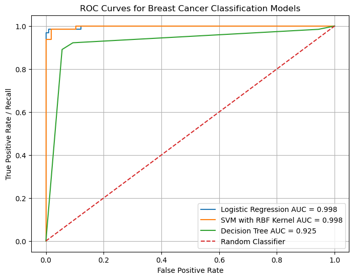

```python
# Plot ROC curves for all models
plt.figure(figsize=(8, 6))

# Convert malignant class into positive class
y_test_malignant = (y_test == 0).astype(int)

for model_name, model in models.items():

    # Get probability scores for malignant class
    malignant_index = list(model.classes_).index(0)
    y_prob = model.predict_proba(X_test)[:, malignant_index]

    # Calculate ROC curve values
    fpr, tpr, thresholds = roc_curve(y_test_malignant, y_prob)

    # Calculate AUC score
    auc = roc_auc_score(y_test_malignant, y_prob)

    # Plot the ROC curve
    plt.plot(fpr, tpr, label=f"{model_name} AUC = {auc:.3f}")

# Add random classifier line
plt.plot([0, 1], [0, 1], linestyle="--", label="Random Classifier")

plt.xlabel("False Positive Rate")
plt.ylabel("True Positive Rate / Recall")
plt.title("ROC Curves for Breast Cancer Classification Models")
plt.legend()
plt.grid(True)
plt.show()
```

### Medical Decision: Precision vs Recall

In this medical problem, recall is more critical than precision. Recall tells us how many actual malignant tumors the model correctly detects.

A false negative means the tumor is actually malignant, but the model predicts it as benign. This is the most dangerous mistake because the patient may not get proper treatment or further testing on time. Missing a malignant tumor can have serious real-world consequences.

A false positive means the tumor is actually benign, but the model predicts it as malignant. This is also not good because it can cause stress and extra medical tests. However, it is usually safer to have a false alarm than to miss a real malignant tumor.

Because of this, I would give more importance to recall than precision for this project.

### Final Recommendation

Based on the results, I would choose Logistic Regression to assist doctors.

Logistic Regression had the best overall balance among the three models. It had the highest accuracy, precision, F1 score, and AUC score. Its malignant recall was 0.969, which means it correctly detected most malignant tumors in the test set.

The SVM model also performed very well and had the same malignant recall as Logistic Regression. However, Logistic Regression had slightly better accuracy, precision, F1 score, and AUC, so I would prefer Logistic Regression overall.

The Decision Tree was easier to understand, but it had lower accuracy, precision, recall, F1 score, and AUC compared to the other two models. This means it was less reliable for this medical diagnosis task.

In this problem, recall is very important because missing a malignant tumor is more serious than creating a false alarm. Since Logistic Regression gives strong recall while also keeping the best overall performance, I would recommend Logistic Regression as the final model.